# Reproducible Research: Peer Assessment 1

## Loading and preprocessing the data

We read the data file **activity.csv** with *read.csv()*, and add a POSIXct date object and a variable to distinguish weekends from weekdays.

We also add a convenience variable **itimes** which represents the intervals as the decimal number of hours in a 24-hour day.

```r
adf <- read.csv('activity.csv')
adf$date <- as.POSIXct(adf$date)
adf$wkday <- weekdays(adf$date)
adf$wkend <- 'weekday'
adf$wkend[adf$wkday=='Saturday' | adf$wkday=='Sunday'] <- 'weekend'

itimes <- seq(0,287) / 12 # 5-minute intervals expressed as hours
```

## What is mean total number of steps taken per day?

We use the *dplyr* library to group observations by day.

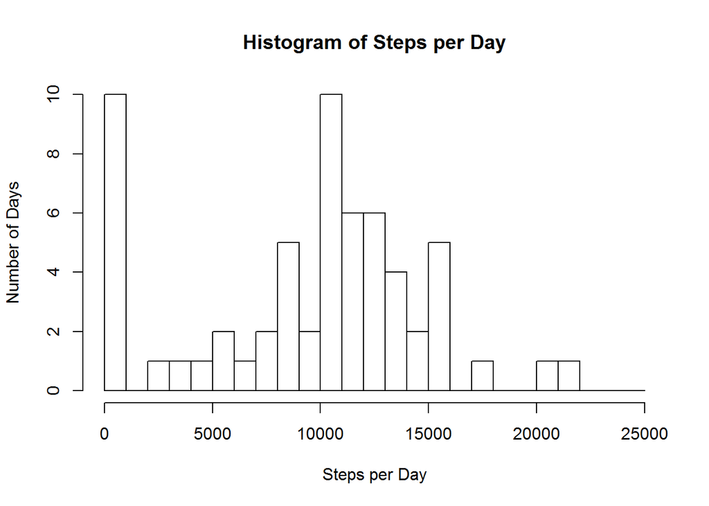

```r
d_adf <- group_by(adf, date)
d_stats <- summarise(d_adf,
                     avsteps=mean(steps,na.rm=TRUE),
                     totsteps=sum(steps,na.rm=TRUE),
                     count=n(),
                     nintvl=length(steps[!is.na(steps)]))

hist(d_stats$totsteps, breaks=seq(0,25000,by=1000),
     main='Histogram of Steps per Day',
     xlab='Steps per Day', ylab='Number of Days')
```

Note that the tall bar at 0 steps includes 8 days of missing (not zero) data.

```r
meanSpD <- mean(d_stats$totsteps, na.rm=TRUE)
medSpD <- median(d_stats$totsteps, na.rm=TRUE)
```

Median number of steps per day: **10395**

Mean number of steps per day: **9354.2295**

## What is the average daily activity pattern?

We use *dplyr* again, this time to group observations by interval.

```r
i_adf <- group_by(adf, interval)
i_stats <- summarise(i_adf,
                     avsteps=mean(steps,na.rm=TRUE),
                     totsteps=sum(steps,na.rm=TRUE),
                     count=n(),
                     ndays=length(steps[!is.na(steps)]))
imax <- which.max(i_stats$avsteps)
intvlMax <- i_stats$interval[imax]
maxHr <- floor(intvlMax / 100.)
maxMin <- intvlMax %% 100
```

Interval with max number of steps is **835** corresponding to a clock time of 8:35.

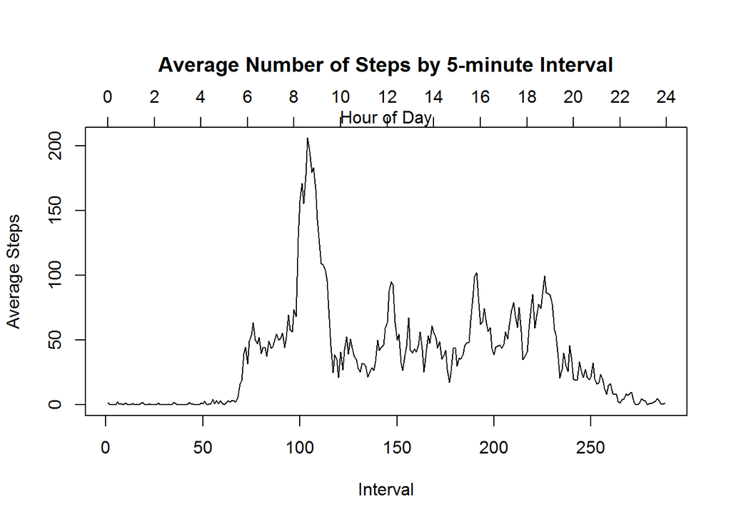

## Imputing missing values

```r
iMiss <- which(is.na(adf$steps))
nMiss <- length(iMiss)
```

There are **2304** intervals with missing data, representing 8 24-hour days with no data. We’ll fill them with the average of the corresponding non-missing values for that interval. (Note that day 2012-11-15 has only 41 steps and 286 no-step intervals, but *NO* missing intervals. We only fill missing data, not zero data, so there will still be zero-valued records in the filled dataset.)

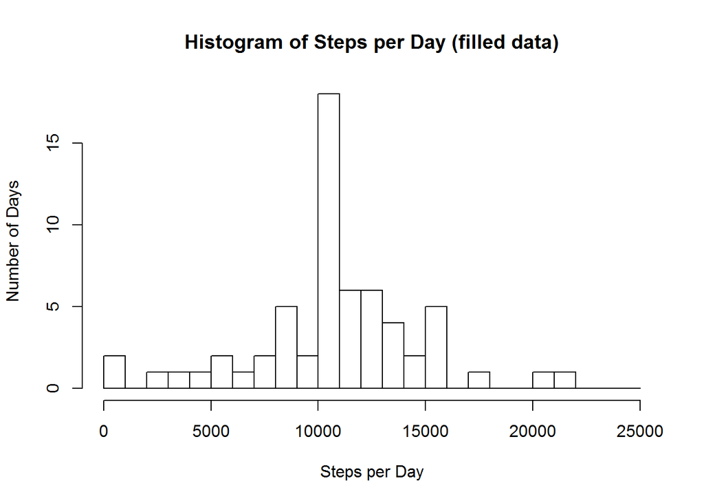

```r
# create a block of data that will be used to fill missing values
# This is more complicated than it needs to be for this case (where complete days are missing)
#   but could be used if random observations were missing.

intvlMiss <- adf$interval[iMiss]
fillVal <- sapply(intvlMiss, function(iv) i_stats$avsteps[which(i_stats$interval==iv)])

adfFill <- adf
adfFill$steps[iMiss] <- fillVal

# use dplyr to summarise by date

dFill_stats <- summarise(group_by(adfFill, date),
                     avsteps=mean(steps,na.rm=TRUE),
                     totsteps=sum(steps,na.rm=TRUE),
                     count=n(),
                     nintvl=length(steps[!is.na(steps)]))

hist(dFill_stats$totsteps, breaks=seq(0,25000,by=1000),
     main='Histogram of Steps per Day (filled data)',
     xlab='Steps per Day', ylab='Number of Days')
```

```r
meanSpD <- mean(dFill_stats$totsteps, na.rm=TRUE)
medSpD <- median(dFill_stats$totsteps, na.rm=TRUE)
```

Median number of steps per day (after filling): **1.0766 × 10<sup>4</sup>**

Mean number of steps per day (after filling): **1.0766 × 10<sup>4</sup>**

Since the filling operation filled in complete days, the effect on the histogram has been to increase the height of the bar containing the average number of steps by 8 (the number of complete days that have been filled.)

## Are there differences in activity patterns between weekdays and weekends?

We use *dplyr* to generate summaries for both weekday and weekend days.

```r
iwd_adf <- group_by(adfFill[adfFill$wkend=='weekday',], interval)
iwd_stats <- summarise(iwd_adf,
                     avsteps=mean(steps,na.rm=TRUE),
                     totsteps=sum(steps,na.rm=TRUE),
                     count=n(),
                     ndays=length(steps[!is.na(steps)]))

iwe_adf <- group_by(adfFill[adfFill$wkend=='weekend',], interval)
iwe_stats <- summarise(iwe_adf,
                     avsteps=mean(steps,na.rm=TRUE),
                     totsteps=sum(steps,na.rm=TRUE),
                     count=n(),
                     ndays=length(steps[!is.na(steps)]))
```

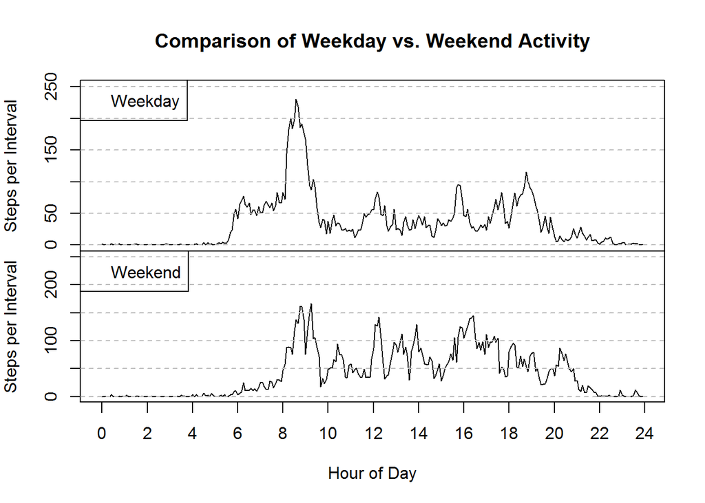

We can see by comparing these two curves that our subject likes to sleep in and stay up later on the weekends.